# Prosper Loan Data Explainitory Report

```python
from IPython.display import Image
```

```python
fig_1 = Image("fig1.png")
fig_2 = Image("fig2.png")
fig_3 = Image("fig3.png")
fig_4 = Image("fig4.png")
fig_5 = Image("fig5.png")
fig_5_2 = Image("fig5_2.png")
fig_6 = Image("fig6.png")
fig_7 = Image("fig7.png")
```

In starting this project I thought different values of loans would be popular at different times of year and this data could be used to target people of different financial status. I discovered that this was not the case. While there is a definite trend to loans being taken out from month to month, it is due to high number of debt consolidation loans offered out. This will be demonstrated in the following figures and an alternative marketing strategy will be suggested at the end.

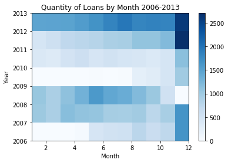

```python
fig_1
```

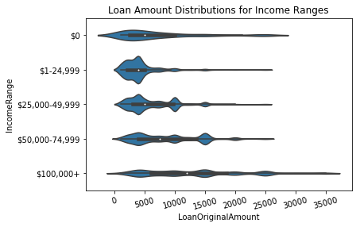

```python
fig_2
```

Figure 2 is a violin plot demonstrating the distribution of loan values across different income ranges. While most tails reach as high as 25000 dollars, lower income ranges tend to have fat distributions in the lower loan amount with long this tails reaching toward the high loan values. A very interesting point to the distributions is that they all bubble around 5000 dollar intervals, suggesting people tend to borrow in intervals of 5000.

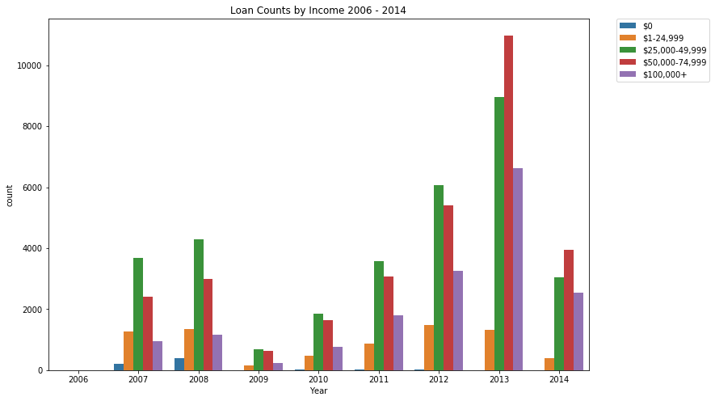

```python
fig_3
```

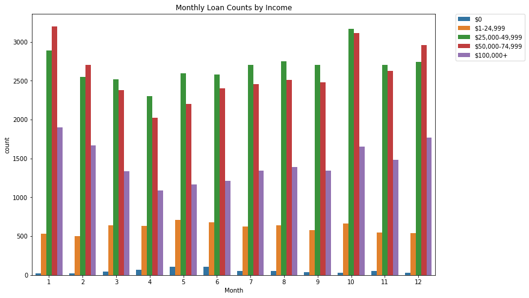

```python
fig_4
```

Figures 3 and 4 are clustered bar charts are loan counts by Year and Month (respectively) with the different income ranges counted individually for each Year/Month. The most interesting thing about these charts are that they contradict what I thought to be true going into this project. I believed that each income range would follow a different trend. However, this wasn't the case. They all follow the same curve (more or less) for both the year and month charts.

Next I decided to look into the type of loans poeple were taking out.

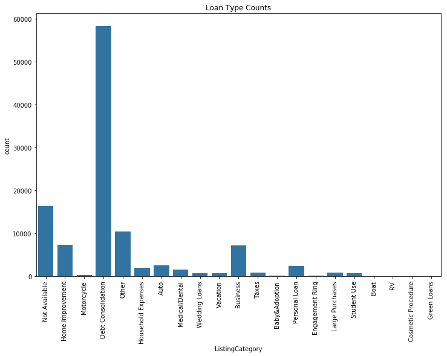

```python
fig_5
```

The quantity of Loans taken out for Debt Consolidation was staggering. Upon further investivation, and demonstrated in the next figure, I discovered that the distribution on Debt Consolidation Loans across the months was very much like the overall distribution I've been observing.

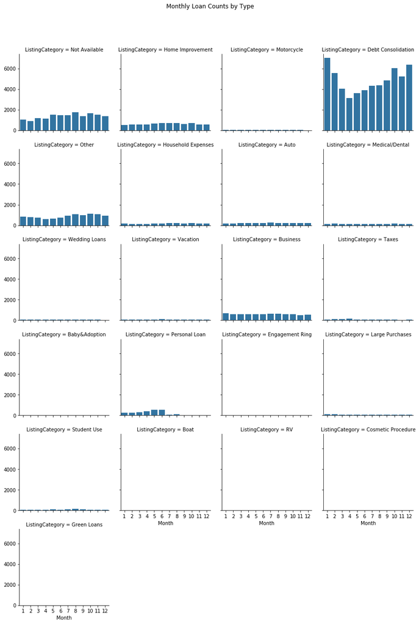

```python
fig_5_2
```

Many of the Loan Types had very low counts and all of them were unobservable relative to Debt Consolidation. I choose a few categories I thought may be of signifigance to work with. The categories I chose can be viewed below.

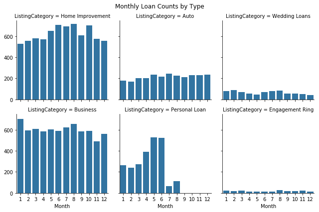

```python
fig_6
```

Though the Engagement Ring and Wedding Loan types had far lower counts than the other categories, I included them because I know these things can be expensive so further analysis may prove them to be very profitable.

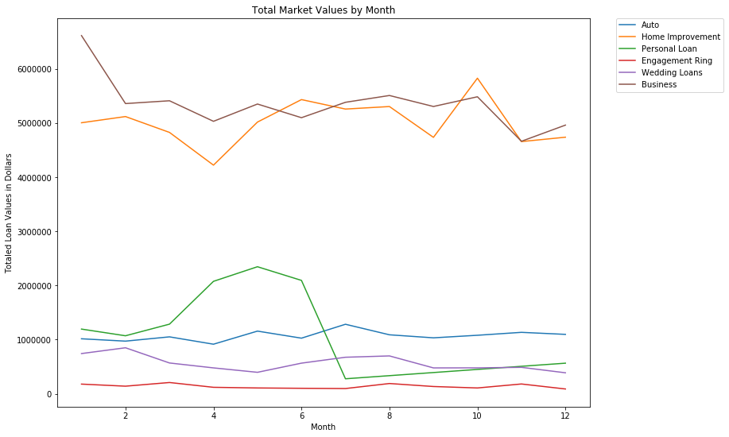

```python
fig_7
```

I separated loans by month and totaled their values to get an idea of how much Prosper has lent out each month (over the years) for each category.

Suggestion: Debt Consolidation is the largest reason for Loans with prosper and is definitely their cash cow, but the marketing team could use this information to develop a series of ads to target specific people at certain times of year though the use of web advertising.